# Análise da Bay Area Bike Share

```python
# Existe algum mês em que as bicicletas são mais utilizadas, existe algum mês em que elas são menos utilizadas?
trip_data.groupby('start_month')['duration'].count()
```

```
start_month
1     52268
2     45425
3     56219
4     57584
5     58042
6     61889
7     63755
8     65221
9     56925
10    63325
11    49735
12    39571
Name: duration, dtype: int64
```

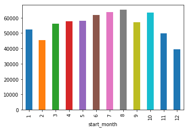

```python
trip_data.groupby('start_month')['duration'].count().plot(kind='bar');
```

#### O mês de fevereiro, novembro e dezembro são os meses aos quais tem menos utilização do serviço. O serviço é mais utilizado no mês de agosto.

```python
trip_data.groupby('start_year')['duration'].count()
```

```
start_year
2013    100563
2014    326339
2015    243057
Name: duration, dtype: int64
```

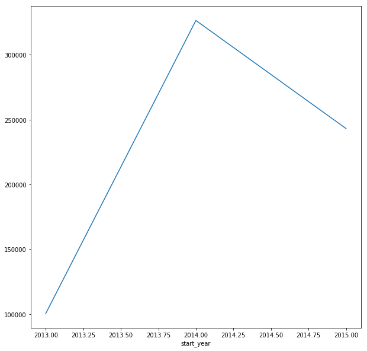

```python
# A utilização vem aumentando ou diminuindo ao longo dos anos?
trip_data.groupby('start_year')['duration'].count().plot(kind='line',figsize=(10,10));
```

```python
trip_data_subscriber = trip_data[trip_data['subscription_type'] == 'Subscriber']
trip_data_subscriber.groupby('start_year')['duration'].count()
```

```
start_year
2013     76064
2014    277763
2015    212919
Name: duration, dtype: int64
```

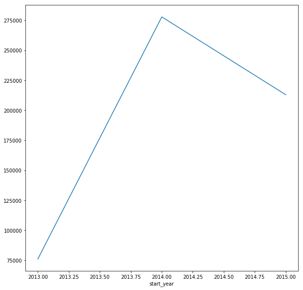

```python
# A utilização por clientes "Subscriber" vem aumentando ou diminuindo ao longo dos anos?
trip_data_subscriber = trip_data[trip_data['subscription_type'] == 'Subscriber']
trip_data_subscriber.groupby('start_year')['duration'].count().plot(kind='line',figsize=(10,10));
```

```python
trip_data_subscriber = trip_data[trip_data['subscription_type'] == 'Customer']
trip_data_subscriber.groupby('start_year')['duration'].count()
```

```
start_year
2013    24499
2014    48576
2015    30138
Name: duration, dtype: int64
```

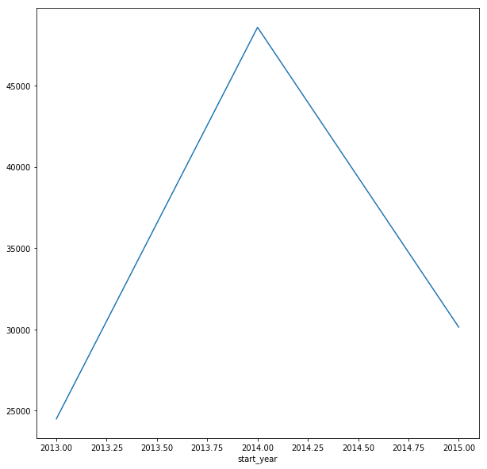

```python
# A utilização por clientes "Customer" vem aumentando ou diminuindo ao longo dos anos?
trip_data_subscriber = trip_data[trip_data['subscription_type'] == 'Customer']
trip_data_subscriber.groupby('start_year')['duration'].count().plot(kind='line',figsize=(10,10));
```

```python
# Cria uma função para recolher os resultados do dicionário e transformar numa lista de valores.
def make_list(dictionary):
    list_make = []
    for i in dictionary:
        list_make.append(i)
    return list_make
```

```python
# Verifica a contagem de valores de horas de partida apenas para dias de semana de clientes "Subscriber"
start_hour_weekday_sub = trip_data_weekday_sub.groupby(['start_hour'])['duration'].count()
start_hour_weekday_sub
```

```
start_hour
0       885
1       351
2       157
3       119
4       865
5      3097
6     13325
7     41312
8     80406
9     55681
10    20761
11    17110
12    21243
13    18703
14    14323
15    20169
16    46325
17    71337
18    48521
19    23110
20    12229
21     7913
22     4794
23     2646
Name: duration, dtype: int64
```

```python
# Cria uma lista de valores para criação do gráfico
subcount = make_list(start_hour_weekday_sub)
subcount
```

```
[885,
 351,
 157,
 119,
 865,
 3097,
 13325,
 41312,
 80406,
 55681,
 20761,
 17110,
 21243,
 18703,
 14323,
 20169,
 46325,
 71337,
 48521,
 23110,
 12229,
 7913,
 4794,
 2646]
```

```python
# Verifica a contagem de valores de horas de partida apenas para dias de semana de clientes "Customer"
start_hour_weekday_cus = trip_data_weekday_cus.groupby(['start_hour'])['duration'].count()
start_hour_weekday_cus
```

```
start_hour
0      348
1      232
2      181
3       82
4       58
5      149
6      508
7     1468
8     2978
9     3036
10    3537
11    4697
12    5108
13    5067
14    5172
15    5304
16    5517
17    5462
18    4336
19    2748
20    1861
21    1514
22    1235
23     803
Name: duration, dtype: int64
```

```python
# Cria uma lista de valores para criação do gráfico
cuscount = make_list(start_hour_weekday_cus)
cuscount
```

```
[348,
 232,
 181,
 82,
 58,
 149,
 508,
 1468,
 2978,
 3036,
 3537,
 4697,
 5108,
 5067,
 5172,
 5304,
 5517,
 5462,
 4336,
 2748,
 1861,
 1514,
 1235,
 803]
```

```python
# Verifica a contagem de valores de horas de partida apenas para dias de fim de semana de clientes "Subscriber"
start_hour_weekend_sub = trip_data_weekend_sub.groupby(['start_hour'])['duration'].count()
start_hour_weekend_sub
```

```
start_hour
0      618
1      330
2      200
3       51
4       47
5      127
6      312
7      719
8     1597
9     2416
10    3101
11    3582
12    3627
13    3470
14    3132
15    3334
16    3283
17    2852
18    2524
19    1856
20    1479
21    1161
22     909
23     637
Name: duration, dtype: int64
```

```python
# Cria uma lista de valores para criação do gráfico
subcountweekend = make_list(start_hour_weekend_sub)
subcountweekend
```

```
[618,
 330,
 200,
 51,
 47,
 127,
 312,
 719,
 1597,
 2416,
 3101,
 3582,
 3627,
 3470,
 3132,
 3334,
 3283,
 2852,
 2524,
 1856,
 1479,
 1161,
 909,
 637]
```

```python
# Verifica a contagem de valores de horas de partida apenas para dias de semana de clientes "Customer"
start_hour_weekend_cus = trip_data_weekend_cus.groupby(['start_hour'])['duration'].count()
start_hour_weekend_cus
```

[output not shown]

```python
# Cria uma lista de valores para criação do gráfico
cuscountweekend = make_list(start_hour_weekend_cus)
cuscountweekend
```

```
[618,
 330,
 200,
 51,
 47,
 127,
 312,
 719,
 1597,
 2416,
 3101,
 3582,
 3627,
 3470,
 3132,
 3334,
 3283,
 2852,
 2524,
 1856,
 1479,
 1161,
 909,
 637]
```

# Pergunta 5a

Explore os dados e faça um gráfico que demonstre alguma particularidade dos dados:

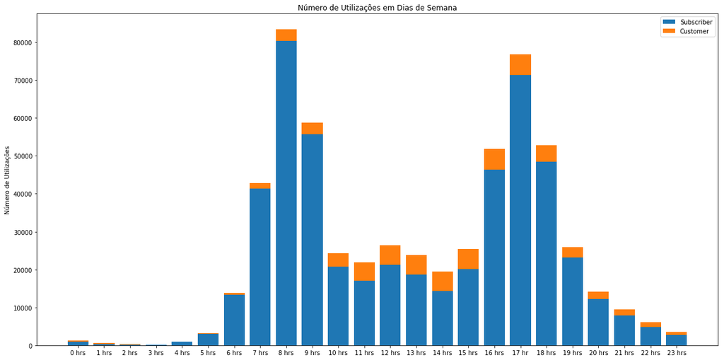

```python
# Gráfico final 1
# Utilização de subscribers x customers durante a semana.
N = start_hour_weekday_cus.count()
ind = np.arange(N)    # the x locations for the groups
width = 0.8       # the width of the bars: can also be len(x) sequence

fig, ax = plt.subplots(figsize=(20, 10))
p1 = plt.bar(ind, subcount, width)
p2 = plt.bar(ind, cuscount, width, bottom=subcount)

plt.ylabel('Número de Utilizações')
plt.title('Número de Utilizações em Dias de Semana')
plt.xticks(ind, ('0 hrs', '1 hrs', '2 hrs', '3 hrs', '4 hrs', '5 hrs', '6 hrs', '7 hrs', '8 hrs', '9 hrs', '10 hrs', '11 hrs', '12 hrs', '13 hrs', '14 hrs', '15 hrs', '16 hrs', '17 hr', '18 hrs', '19 hrs', '20 hrs', '21 hrs', '22 hrs', '23 hrs'))
plt.yticks(np.arange(0, 90000, 10000))
plt.legend((p1[0], p2[0]), ('Subscriber', 'Customer'))
```

O que é interessante na visualização acima? Por que você a selecionou?

**Answer**: A visualização acima nos permite ver com clareza o perfil de uso durante um dia de semana típico e o interesse relativo entre os diferentes tipos de usuários. O gráfico demonstra que durante a semana o serviço é utilizado em sua grande maioria pelos clientes do tipo "Subscriber" que utilizam o serviço principalmente nos horários típicos de entrada e saída de trabalho (entre 7 as 9, pela manhã, e entre 16 as 19, pela noite). É possível interpretar por esse resultado que o serviço é utilizado como meio de transporte para a jornada de trabalho (ainda que possivelmnete de forma complementar). Ainda é perceptível que existe uma pequena predileção pelo uso dos serviços por estes usuários pela manhã em relação a noite. Por outro lado, os usuários "Customers" tem uma utilização mais uniforme e concentram mais sua utilização nos horários típicos de lazer (de 10 as 18 horas).

# Pergunta 5b

Faça um gráfico que demonstre alguma particularidade dos dados:

[figure not shown]

```python
# Gráfico Final 2
# Utilização de subscribers x customers durante o fim de semana.
N = start_hour_weekend_cus.count()
ind = np.arange(N)    # the x locations for the groups
width = 0.8       # the width of the bars: can also be len(x) sequence

fig, ax = plt.subplots(figsize=(20, 10))
p1 = plt.bar(ind, subcountweekend, width)
p2 = plt.bar(ind, cuscountweekend, width, bottom=subcountweekend)

plt.ylabel('Número de Utilizações')
plt.title('Número de Utilizações em Fins de Semana')
plt.xticks(ind, ('0 hrs', '1 hrs', '2 hrs', '3 hrs', '4 hrs', '5 hrs', '6 hrs', '7 hrs', '8 hrs', '9 hrs', '10 hrs', '11 hrs', '12 hrs', '13 hrs', '14 hrs', '15 hrs', '16 hrs', '17 hr', '18 hrs', '19 hrs', '20 hrs', '21 hrs', '22 hrs', '23 hrs'))
plt.yticks(np.arange(0, 10000, 1000))
plt.legend((p1[0], p2[0]), ('Subscriber', 'Customer'))
```

## Conclusões

Parabéns pela conclusão do projeto! Esta é apenas uma amostragem do processo de análise de dados: gerando perguntas, limpando e explorando os dados. Normalmente, neste momento no processo de análise de dados, você pode querer tirar conclusões realizando um teste estatístico ou ajustando os dados a um modelo para fazer previsões. Há também muitas análises potenciais que podem ser realizadas se evoluirmos o código fornecido. Em vez de apenas olhar para o número de viagens no eixo de resultados, você pode ver quais recursos afetam coisas como a duração da viagem. Nós também não analisamos como os dados meteorológicos se encaixam no uso de bicicletas.

# Pergunta 6

Pense em um tópico ou campo de interesse onde você gostaria de poder aplicar as técnicas da ciência dos dados. O que você gostaria de aprender com o assunto escolhido?

**Responda**: Gostaria de aplicar as técnicas da ciências dos dados a dois tópicos de interesse.

**Escolha de produtos (escolhas do consumidor)**. É interessante utilizar essa abordagem para esse assunto pois permite a criação de produtos e serviços mais adequados aos clientes. A partir da análise de dados é possível prever tendências e descobrir insights tanto de novos serviços e produtos como para melhorar os já existentes. Seria interessante encontrar formas de ampliar a escala de certos produtos sem perder a conexão "premium" de clientes com marcas feitas sobre medida. Acredito que a análise de dados somada com outras técnicas nos permite se aproximar desse objetivo.

**Decisões políticas**. As nossas eleições estão chegando e é interessante utilizar as técnicas de análise de dados para descobrir o que influencia nas decisões políticas dos individuos. Historicamente temos a sensação de nossas decisões políticas como população não estão nos direcionando para os objetivos que nós queremos (uma sociedade mais justa, igualitária, com liberdade e solidariedade). Seria interessante utilizar as técnicas de análise de dados para descobrir insights interessantes de porque as pessoas decidem por um ou por outro candidato, e por que após eleitos eles não satisfazem as expectativas depositadas pela população.

> **Dica**: se quisermos compartilhar os resultados de nossa análise com os outros, existe uma outra opção que não é enviar o arquivo jupyter Notebook (.ipynb). Também podemos exportar a saída do Notebook de uma forma que pode ser aberto mesmo para aqueles sem o Python instalado. No menu **File** na parte superior esquerda, vá para o submenu **Download as**. Você pode então escolher um formato diferente que pode ser visto de forma mais geral, como HTML (.html) ou PDF (.pdf). Você pode precisar de pacotes adicionais ou software para executar essas exportações.